# Risk Factor Analysis

## Outcome Variable

**Outcome Variable:** stunted

## Predictor Variables

**Intervention Variable:** mhtcm

**Adjustment Set:**

unadjusted

## Stratifying Variables

The analysis was stratified on these variable(s):

- agecat
- studyid

The following strata were considered:

- agecat: 12 months, studyid: ki0047075b-MAL-ED
- agecat: 12 months, studyid: ki1000304b-SAS-FoodSuppl
- agecat: 12 months, studyid: ki1017093-NIH-Birth
- agecat: 12 months, studyid: ki1017093b-PROVIDE
- agecat: 12 months, studyid: ki1017093c-NIH-Crypto
- agecat: 12 months, studyid: ki1066203-TanzaniaChild2
- agecat: 12 months, studyid: ki1101329-Keneba
- agecat: 12 months, studyid: ki1112895-Guatemala BSC
- agecat: 12 months, studyid: ki1126311-ZVITAMBO
- agecat: 12 months, studyid: ki1135781-COHORTS
- agecat: 12 months, studyid: ki1148112-LCNI-5
- agecat: 18 months, studyid: ki0047075b-MAL-ED
- agecat: 18 months, studyid: ki1000304b-SAS-FoodSuppl
- agecat: 18 months, studyid: ki1017093-NIH-Birth
- agecat: 18 months, studyid: ki1017093b-PROVIDE
- agecat: 18 months, studyid: ki1017093c-NIH-Crypto
- agecat: 18 months, studyid: ki1066203-TanzaniaChild2
- agecat: 18 months, studyid: ki1101329-Keneba
- agecat: 18 months, studyid: ki1126311-ZVITAMBO
- agecat: 18 months, studyid: ki1135781-COHORTS
- agecat: 18 months, studyid: ki1148112-LCNI-5
- agecat: 24 months, studyid: ki0047075b-MAL-ED
- agecat: 24 months, studyid: ki1017093-NIH-Birth
- agecat: 24 months, studyid: ki1017093b-PROVIDE
- agecat: 24 months, studyid: ki1017093c-NIH-Crypto
- agecat: 24 months, studyid: ki1066203-TanzaniaChild2
- agecat: 24 months, studyid: ki1101329-Keneba
- agecat: 24 months, studyid: ki1126311-ZVITAMBO
- agecat: 24 months, studyid: ki1135781-COHORTS
- agecat: 24 months, studyid: ki1148112-LCNI-5
- agecat: 3 months, studyid: ki0047075b-MAL-ED
- agecat: 3 months, studyid: ki1000304b-SAS-FoodSuppl
- agecat: 3 months, studyid: ki1017093-NIH-Birth
- agecat: 3 months, studyid: ki1017093b-PROVIDE
- agecat: 3 months, studyid: ki1017093c-NIH-Crypto
- agecat: 3 months, studyid: ki1066203-TanzaniaChild2
- agecat: 3 months, studyid: ki1101329-Keneba
- agecat: 3 months, studyid: ki1112895-Guatemala BSC
- agecat: 3 months, studyid: ki1126311-ZVITAMBO
- agecat: 3 months, studyid: ki1135781-COHORTS
- agecat: 6 months, studyid: ki0047075b-MAL-ED
- agecat: 6 months, studyid: ki1000304b-SAS-FoodSuppl
- agecat: 6 months, studyid: ki1017093-NIH-Birth
- agecat: 6 months, studyid: ki1017093b-PROVIDE
- agecat: 6 months, studyid: ki1017093c-NIH-Crypto
- agecat: 6 months, studyid: ki1066203-TanzaniaChild2
- agecat: 6 months, studyid: ki1101329-Keneba
- agecat: 6 months, studyid: ki1112895-Guatemala BSC
- agecat: 6 months, studyid: ki1126311-ZVITAMBO
- agecat: 6 months, studyid: ki1135781-COHORTS
- agecat: 6 months, studyid: ki1148112-LCNI-5
- agecat: 9 months, studyid: ki0047075b-MAL-ED
- agecat: 9 months, studyid: ki1000304b-SAS-FoodSuppl
- agecat: 9 months, studyid: ki1017093-NIH-Birth
- agecat: 9 months, studyid: ki1017093b-PROVIDE
- agecat: 9 months, studyid: ki1017093c-NIH-Crypto
- agecat: 9 months, studyid: ki1066203-TanzaniaChild2
- agecat: 9 months, studyid: ki1101329-Keneba
- agecat: 9 months, studyid: ki1112895-Guatemala BSC
- agecat: 9 months, studyid: ki1126311-ZVITAMBO
- agecat: 9 months, studyid: ki1135781-COHORTS
- agecat: 9 months, studyid: ki1148112-LCNI-5
- agecat: Birth, studyid: ki0047075b-MAL-ED
- agecat: Birth, studyid: ki1017093-NIH-Birth
- agecat: Birth, studyid: ki1017093c-NIH-Crypto
- agecat: Birth, studyid: ki1101329-Keneba
- agecat: Birth, studyid: ki1126311-ZVITAMBO
- agecat: Birth, studyid: ki1135781-COHORTS

### Dropped Strata

Some strata were dropped due to rare outcomes:

- agecat: 12 months, studyid: ki1000304b-SAS-FoodSuppl
- agecat: 12 months, studyid: ki1017093-NIH-Birth
- agecat: 12 months, studyid: ki1017093b-PROVIDE
- agecat: 12 months, studyid: ki1017093c-NIH-Crypto
- agecat: 12 months, studyid: ki1112895-Guatemala BSC
- agecat: 18 months, studyid: ki1000304b-SAS-FoodSuppl
- agecat: 18 months, studyid: ki1017093-NIH-Birth
- agecat: 18 months, studyid: ki1017093b-PROVIDE
- agecat: 18 months, studyid: ki1017093c-NIH-Crypto
- agecat: 18 months, studyid: ki1126311-ZVITAMBO
- agecat: 24 months, studyid: ki1017093-NIH-Birth
- agecat: 24 months, studyid: ki1017093b-PROVIDE
- agecat: 24 months, studyid: ki1017093c-NIH-Crypto
- agecat: 24 months, studyid: ki1066203-TanzaniaChild2
- agecat: 24 months, studyid: ki1126311-ZVITAMBO
- agecat: 3 months, studyid: ki1000304b-SAS-FoodSuppl
- agecat: 3 months, studyid: ki1017093-NIH-Birth
- agecat: 3 months, studyid: ki1017093b-PROVIDE
- agecat: 3 months, studyid: ki1017093c-NIH-Crypto
- agecat: 3 months, studyid: ki1112895-Guatemala BSC
- agecat: 6 months, studyid: ki1000304b-SAS-FoodSuppl
- agecat: 6 months, studyid: ki1017093-NIH-Birth
- agecat: 6 months, studyid: ki1017093b-PROVIDE
- agecat: 6 months, studyid: ki1017093c-NIH-Crypto
- agecat: 6 months, studyid: ki1112895-Guatemala BSC
- agecat: 9 months, studyid: ki1000304b-SAS-FoodSuppl
- agecat: 9 months, studyid: ki1017093-NIH-Birth
- agecat: 9 months, studyid: ki1017093b-PROVIDE
- agecat: 9 months, studyid: ki1017093c-NIH-Crypto
- agecat: 9 months, studyid: ki1112895-Guatemala BSC
- agecat: Birth, studyid: ki1017093-NIH-Birth
- agecat: Birth, studyid: ki1017093c-NIH-Crypto
- agecat: Birth, studyid: ki1101329-Keneba

## Methods Detail

We’re interested in the causal parameters $E[Y_a]$ for all values of $a \in \mathcal{A}$. These parameters represent the mean outcome if, possibly contrary to fact, we intervened to set all units to have $A=a$. Under the randomization and positivity assumptions, these are identified by the statistical parameters $\psi_a=E_W[E_{Y|A,W}(Y|A=a,W)]$. In addition, we’re interested in the mean of $Y$, $E[Y]$ under no intervention (the observed mean). We will estimate these parameters by using SuperLearner to fit the relevant likelihood factors – $E_{Y|A,W}(Y|A=a,W)$ and $p(A=a|W)$, and then updating our likelihood fit using a joint TMLE.

For unadjusted analyses ($W=\{\}$), initial likelihoods were estimated using Lrnr_glm to estimate the simple $E(Y|A)$ and Lrnr_mean to estimate $p(A)$. For adjusted analyses, a small library containing Lrnr_glmnet, Lrnr_xgboost, and Lrnr_mean was used.

Having estimated these parameters, we will then use the delta method to estimate relative risks and attributable risks relative to a prespecified baseline level of $A$.

# Results Detail

## Results Plots

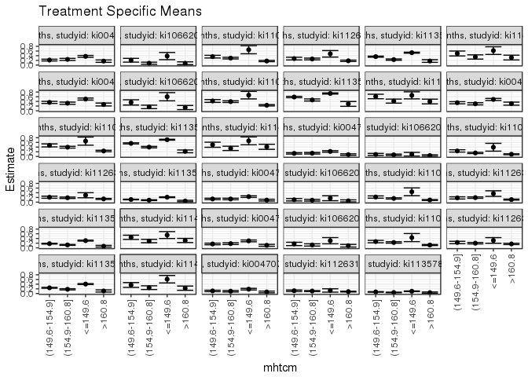

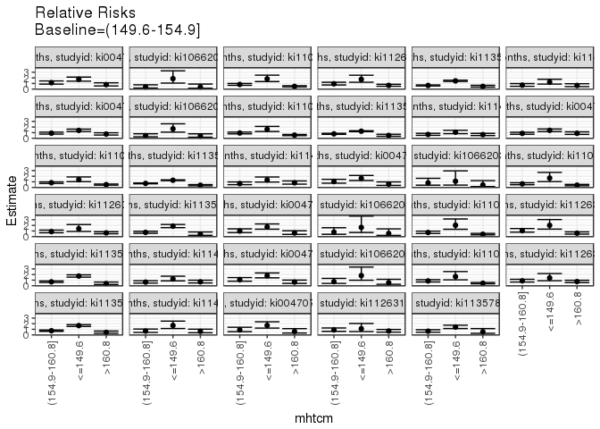

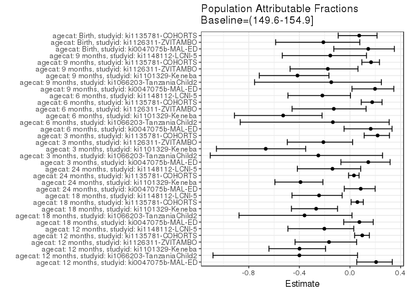

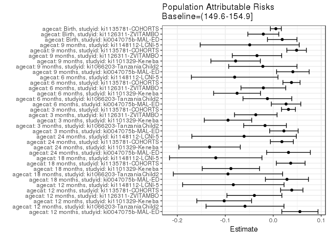

## Data Summary

| agecat | studyid | A | n | nA | nAY0 | nAY1 |
| --- | --- | --- | --- | --- | --- | --- |
| 12 months | ki0047075b-MAL-ED | (149.6-154.9] | 1610 | 458 | 360 | 98 |
| 12 months | ki0047075b-MAL-ED | (154.9-160.8] | 1610 | 391 | 296 | 95 |
| 12 months | ki0047075b-MAL-ED | <=149.6 | 1610 | 554 | 348 | 206 |
| 12 months | ki0047075b-MAL-ED | >160.8 | 1610 | 207 | 172 | 35 |
| 12 months | ki1000304b-SAS-FoodSuppl | (149.6-154.9] | 92 | 30 | 7 | 23 |
| 12 months | ki1000304b-SAS-FoodSuppl | (154.9-160.8] | 92 | 15 | 6 | 9 |
| 12 months | ki1000304b-SAS-FoodSuppl | <=149.6 | 92 | 46 | 6 | 40 |
| 12 months | ki1000304b-SAS-FoodSuppl | >160.8 | 92 | 1 | 0 | 1 |
| 12 months | ki1017093-NIH-Birth | (149.6-154.9] | 491 | 150 | 106 | 44 |
| 12 months | ki1017093-NIH-Birth | (154.9-160.8] | 491 | 80 | 65 | 15 |
| 12 months | ki1017093-NIH-Birth | <=149.6 | 491 | 249 | 124 | 125 |
| 12 months | ki1017093-NIH-Birth | >160.8 | 491 | 12 | 12 | 0 |
| 12 months | ki1017093b-PROVIDE | (149.6-154.9] | 153 | 45 | 37 | 8 |
| 12 months | ki1017093b-PROVIDE | (154.9-160.8] | 153 | 29 | 23 | 6 |
| 12 months | ki1017093b-PROVIDE | <=149.6 | 153 | 72 | 42 | 30 |
| 12 months | ki1017093b-PROVIDE | >160.8 | 153 | 7 | 7 | 0 |
| 12 months | ki1017093c-NIH-Crypto | (149.6-154.9] | 706 | 248 | 195 | 53 |
| 12 months | ki1017093c-NIH-Crypto | (154.9-160.8] | 706 | 118 | 101 | 17 |
| 12 months | ki1017093c-NIH-Crypto | <=149.6 | 706 | 325 | 224 | 101 |
| 12 months | ki1017093c-NIH-Crypto | >160.8 | 706 | 15 | 15 | 0 |
| 12 months | ki1066203-TanzaniaChild2 | (149.6-154.9] | 353 | 97 | 77 | 20 |
| 12 months | ki1066203-TanzaniaChild2 | (154.9-160.8] | 353 | 140 | 129 | 11 |
| 12 months | ki1066203-TanzaniaChild2 | <=149.6 | 353 | 39 | 24 | 15 |
| 12 months | ki1066203-TanzaniaChild2 | >160.8 | 353 | 77 | 71 | 6 |
| 12 months | ki1101329-Keneba | (149.6-154.9] | 1773 | 273 | 175 | 98 |
| 12 months | ki1101329-Keneba | (154.9-160.8] | 1773 | 670 | 471 | 199 |
| 12 months | ki1101329-Keneba | <=149.6 | 1773 | 29 | 10 | 19 |
| 12 months | ki1101329-Keneba | >160.8 | 1773 | 801 | 662 | 139 |
| 12 months | ki1112895-Guatemala BSC | (149.6-154.9] | 46 | 12 | 8 | 4 |
| 12 months | ki1112895-Guatemala BSC | (154.9-160.8] | 46 | 5 | 4 | 1 |

[output cut: 278 more lines]

## Results Table

### Parameter: TSM

| agecat | studyid | intervention_level | baseline_level | estimate | ci_lower | ci_upper |
| --- | --- | --- | --- | --- | --- | --- |
| 12 months | ki0047075b-MAL-ED | (149.6-154.9] | NA | 0.2139738 | 0.1764031 | 0.2515445 |
| 12 months | ki0047075b-MAL-ED | (154.9-160.8] | NA | 0.2429668 | 0.2004436 | 0.2854899 |
| 12 months | ki0047075b-MAL-ED | <=149.6 | NA | 0.3718412 | 0.3315841 | 0.4120982 |
| 12 months | ki0047075b-MAL-ED | >160.8 | NA | 0.1690821 | 0.1180051 | 0.2201592 |
| 12 months | ki1066203-TanzaniaChild2 | (149.6-154.9] | NA | 0.2061856 | 0.1255611 | 0.2868100 |
| 12 months | ki1066203-TanzaniaChild2 | (154.9-160.8] | NA | 0.0785714 | 0.0339377 | 0.1232052 |
| 12 months | ki1066203-TanzaniaChild2 | <=149.6 | NA | 0.3846154 | 0.2317115 | 0.5375192 |
| 12 months | ki1066203-TanzaniaChild2 | >160.8 | NA | 0.0779221 | 0.0179661 | 0.1378781 |
| 12 months | ki1101329-Keneba | (149.6-154.9] | NA | 0.3589744 | 0.3020552 | 0.4158935 |
| 12 months | ki1101329-Keneba | (154.9-160.8] | NA | 0.2970149 | 0.2624054 | 0.3316244 |
| 12 months | ki1101329-Keneba | <=149.6 | NA | 0.6551724 | 0.4821309 | 0.8282140 |
| 12 months | ki1101329-Keneba | >160.8 | NA | 0.1735331 | 0.1472995 | 0.1997667 |
| 12 months | ki1126311-ZVITAMBO | (149.6-154.9] | NA | 0.2765957 | 0.2193851 | 0.3338064 |
| 12 months | ki1126311-ZVITAMBO | (154.9-160.8] | NA | 0.2610294 | 0.2241099 | 0.2979490 |
| 12 months | ki1126311-ZVITAMBO | <=149.6 | NA | 0.4800000 | 0.3414729 | 0.6185271 |
| 12 months | ki1126311-ZVITAMBO | >160.8 | NA | 0.1824000 | 0.1521141 | 0.2126859 |
| 12 months | ki1135781-COHORTS | (149.6-154.9] | NA | 0.3601441 | 0.3370906 | 0.3831976 |
| 12 months | ki1135781-COHORTS | (154.9-160.8] | NA | 0.2340183 | 0.2059783 | 0.2620582 |
| 12 months | ki1135781-COHORTS | <=149.6 | NA | 0.5282427 | 0.5058644 | 0.5506210 |
| 12 months | ki1135781-COHORTS | >160.8 | NA | 0.1734104 | 0.1169876 | 0.2298332 |
| 12 months | ki1148112-LCNI-5 | (149.6-154.9] | NA | 0.4942529 | 0.3890243 | 0.5994814 |
| 12 months | ki1148112-LCNI-5 | (154.9-160.8] | NA | 0.3457944 | 0.2555280 | 0.4360608 |
| 12 months | ki1148112-LCNI-5 | <=149.6 | NA | 0.6176471 | 0.4540351 | 0.7812590 |
| 12 months | ki1148112-LCNI-5 | >160.8 | NA | 0.3209877 | 0.2191537 | 0.4228216 |
| 18 months | ki0047075b-MAL-ED | (149.6-154.9] | NA | 0.3574661 | 0.3127727 | 0.4021595 |
| 18 months | ki0047075b-MAL-ED | (154.9-160.8] | NA | 0.3226667 | 0.2753350 | 0.3699983 |
| 18 months | ki0047075b-MAL-ED | <=149.6 | NA | 0.5000000 | 0.4572569 | 0.5427431 |
| 18 months | ki0047075b-MAL-ED | >160.8 | NA | 0.2676768 | 0.2059870 | 0.3293665 |
| 18 months | ki1066203-TanzaniaChild2 | (149.6-154.9] | NA | 0.3571429 | 0.2446745 | 0.4696113 |
| 18 months | ki1066203-TanzaniaChild2 | (154.9-160.8] | NA | 0.1649485 | 0.0909460 | 0.2389509 |

[output cut: 110 more lines]

### Parameter: E(Y)

| agecat | studyid | intervention_level | baseline_level | estimate | ci_lower | ci_upper |
| --- | --- | --- | --- | --- | --- | --- |
| 12 months | ki0047075b-MAL-ED | NA | NA | 0.2695652 | 0.2657967 | 0.2733338 |
| 12 months | ki1066203-TanzaniaChild2 | NA | NA | 0.1473088 | 0.1368109 | 0.1578067 |
| 12 months | ki1101329-Keneba | NA | NA | 0.2566272 | 0.2524766 | 0.2607778 |
| 12 months | ki1126311-ZVITAMBO | NA | NA | 0.2372765 | 0.2341146 | 0.2404383 |
| 12 months | ki1135781-COHORTS | NA | NA | 0.3987465 | 0.3952763 | 0.4022167 |
| 12 months | ki1148112-LCNI-5 | NA | NA | 0.4110032 | 0.3996986 | 0.4223079 |
| 18 months | ki0047075b-MAL-ED | NA | NA | 0.3861129 | 0.3818036 | 0.3904222 |
| 18 months | ki1066203-TanzaniaChild2 | NA | NA | 0.2627451 | 0.2440908 | 0.2813994 |
| 18 months | ki1101329-Keneba | NA | NA | 0.3299492 | 0.3255952 | 0.3343032 |
| 18 months | ki1135781-COHORTS | NA | NA | 0.6234079 | 0.6191926 | 0.6276233 |
| 18 months | ki1148112-LCNI-5 | NA | NA | 0.4901408 | 0.4789801 | 0.5013016 |
| 24 months | ki0047075b-MAL-ED | NA | NA | 0.3746631 | 0.3705718 | 0.3787544 |
| 24 months | ki1101329-Keneba | NA | NA | 0.3395755 | 0.3345476 | 0.3446034 |
| 24 months | ki1135781-COHORTS | NA | NA | 0.5765823 | 0.5726317 | 0.5805329 |
| 24 months | ki1148112-LCNI-5 | NA | NA | 0.4391892 | 0.4280652 | 0.4503131 |
| 3 months | ki0047075b-MAL-ED | NA | NA | 0.1539773 | 0.1518082 | 0.1561464 |
| 3 months | ki1066203-TanzaniaChild2 | NA | NA | 0.0684211 | 0.0668696 | 0.0699725 |
| 3 months | ki1101329-Keneba | NA | NA | 0.1416111 | 0.1390217 | 0.1442005 |
| 3 months | ki1126311-ZVITAMBO | NA | NA | 0.1734164 | 0.1717848 | 0.1750481 |
| 3 months | ki1135781-COHORTS | NA | NA | 0.1453488 | 0.1438159 | 0.1468817 |
| 6 months | ki0047075b-MAL-ED | NA | NA | 0.1634103 | 0.1608313 | 0.1659893 |
| 6 months | ki1066203-TanzaniaChild2 | NA | NA | 0.0900000 | 0.0873870 | 0.0926130 |
| 6 months | ki1101329-Keneba | NA | NA | 0.1427810 | 0.1400172 | 0.1455449 |
| 6 months | ki1126311-ZVITAMBO | NA | NA | 0.1611991 | 0.1586066 | 0.1637916 |
| 6 months | ki1135781-COHORTS | NA | NA | 0.2168675 | 0.2146475 | 0.2190875 |
| 6 months | ki1148112-LCNI-5 | NA | NA | 0.3686747 | 0.3600157 | 0.3773337 |
| 9 months | ki0047075b-MAL-ED | NA | NA | 0.2068543 | 0.2035204 | 0.2101883 |
| 9 months | ki1066203-TanzaniaChild2 | NA | NA | 0.1465116 | 0.1407467 | 0.1522766 |
| 9 months | ki1101329-Keneba | NA | NA | 0.1891026 | 0.1859742 | 0.1922309 |
| 9 months | ki1126311-ZVITAMBO | NA | NA | 0.1935484 | 0.1920502 | 0.1950465 |
| 9 months | ki1135781-COHORTS | NA | NA | 0.2927947 | 0.2900283 | 0.2955611 |
| 9 months | ki1148112-LCNI-5 | NA | NA | 0.3156250 | 0.3026529 | 0.3285971 |
| Birth | ki0047075b-MAL-ED | NA | NA | 0.1298246 | 0.1275150 | 0.1321341 |
| Birth | ki1126311-ZVITAMBO | NA | NA | 0.0982031 | 0.0975851 | 0.0988210 |
| Birth | ki1135781-COHORTS | NA | NA | 0.0746983 | 0.0741435 | 0.0752531 |

### Parameter: RR

| agecat | studyid | intervention_level | baseline_level | estimate | ci_lower | ci_upper |
| --- | --- | --- | --- | --- | --- | --- |
| 12 months | ki0047075b-MAL-ED | (154.9-160.8] | (149.6-154.9] | 1.1354977 | 0.8861738 | 1.4549685 |
| 12 months | ki0047075b-MAL-ED | <=149.6 | (149.6-154.9] | 1.7377883 | 1.4138740 | 2.1359104 |
| 12 months | ki0047075b-MAL-ED | >160.8 | (149.6-154.9] | 0.7902001 | 0.5571750 | 1.1206824 |
| 12 months | ki1066203-TanzaniaChild2 | (154.9-160.8] | (149.6-154.9] | 0.3810714 | 0.1912053 | 0.7594739 |
| 12 months | ki1066203-TanzaniaChild2 | <=149.6 | (149.6-154.9] | 1.8653846 | 1.0680546 | 3.2579419 |
| 12 months | ki1066203-TanzaniaChild2 | >160.8 | (149.6-154.9] | 0.3779221 | 0.1594279 | 0.8958599 |
| 12 months | ki1101329-Keneba | (154.9-160.8] | (149.6-154.9] | 0.8273987 | 0.6796067 | 1.0073307 |
| 12 months | ki1101329-Keneba | <=149.6 | (149.6-154.9] | 1.8251232 | 1.3412353 | 2.4835870 |
| 12 months | ki1101329-Keneba | >160.8 | (149.6-154.9] | 0.4834136 | 0.3883066 | 0.6018149 |
| 12 months | ki1126311-ZVITAMBO | (154.9-160.8] | (149.6-154.9] | 0.9437217 | 0.7345500 | 1.2124575 |
| 12 months | ki1126311-ZVITAMBO | <=149.6 | (149.6-154.9] | 1.7353846 | 1.2167267 | 2.4751325 |
| 12 months | ki1126311-ZVITAMBO | >160.8 | (149.6-154.9] | 0.6594462 | 0.5058100 | 0.8597481 |
| 12 months | ki1135781-COHORTS | (154.9-160.8] | (149.6-154.9] | 0.6497907 | 0.5672522 | 0.7443390 |
| 12 months | ki1135781-COHORTS | <=149.6 | (149.6-154.9] | 1.4667538 | 1.3583776 | 1.5837768 |
| 12 months | ki1135781-COHORTS | >160.8 | (149.6-154.9] | 0.4815029 | 0.3456076 | 0.6708332 |
| 12 months | ki1148112-LCNI-5 | (154.9-160.8] | (149.6-154.9] | 0.6996305 | 0.4995454 | 0.9798565 |
| 12 months | ki1148112-LCNI-5 | <=149.6 | (149.6-154.9] | 1.2496580 | 0.8896031 | 1.7554402 |
| 12 months | ki1148112-LCNI-5 | >160.8 | (149.6-154.9] | 0.6494401 | 0.4432090 | 0.9516335 |
| 18 months | ki0047075b-MAL-ED | (154.9-160.8] | (149.6-154.9] | 0.9026498 | 0.7444100 | 1.0945268 |
| 18 months | ki0047075b-MAL-ED | <=149.6 | (149.6-154.9] | 1.3987342 | 1.2021458 | 1.6274709 |
| 18 months | ki0047075b-MAL-ED | >160.8 | (149.6-154.9] | 0.7488173 | 0.5761115 | 0.9732966 |
| 18 months | ki1066203-TanzaniaChild2 | (154.9-160.8] | (149.6-154.9] | 0.4618557 | 0.2669662 | 0.7990176 |
| 18 months | ki1066203-TanzaniaChild2 | <=149.6 | (149.6-154.9] | 1.6800000 | 1.0928920 | 2.5825059 |
| 18 months | ki1066203-TanzaniaChild2 | >160.8 | (149.6-154.9] | 0.3862069 | 0.1884651 | 0.7914238 |
| 18 months | ki1101329-Keneba | (154.9-160.8] | (149.6-154.9] | 0.9332935 | 0.7869159 | 1.1068993 |
| 18 months | ki1101329-Keneba | <=149.6 | (149.6-154.9] | 1.5939394 | 1.2043203 | 2.1096072 |
| 18 months | ki1101329-Keneba | >160.8 | (149.6-154.9] | 0.5607933 | 0.4636980 | 0.6782198 |
| 18 months | ki1135781-COHORTS | (154.9-160.8] | (149.6-154.9] | 0.7850063 | 0.7048371 | 0.8742941 |
| 18 months | ki1135781-COHORTS | <=149.6 | (149.6-154.9] | 1.2547277 | 1.1813200 | 1.3326969 |
| 18 months | ki1135781-COHORTS | >160.8 | (149.6-154.9] | 0.4997531 | 0.3504305 | 0.7127038 |

[output cut: 75 more lines]

### Parameter: PAR

| agecat | studyid | intervention_level | baseline_level | estimate | ci_lower | ci_upper |
| --- | --- | --- | --- | --- | --- | --- |
| 12 months | ki0047075b-MAL-ED | (149.6-154.9] | NA | 0.0555914 | 0.0178322 | 0.0933506 |
| 12 months | ki1066203-TanzaniaChild2 | (149.6-154.9] | NA | -0.0588768 | -0.1401818 | 0.0224283 |
| 12 months | ki1101329-Keneba | (149.6-154.9] | NA | -0.1023472 | -0.1594175 | -0.0452769 |
| 12 months | ki1126311-ZVITAMBO | (149.6-154.9] | NA | -0.0393193 | -0.0966172 | 0.0179787 |
| 12 months | ki1135781-COHORTS | (149.6-154.9] | NA | 0.0386024 | 0.0152892 | 0.0619156 |
| 12 months | ki1148112-LCNI-5 | (149.6-154.9] | NA | -0.0832496 | -0.1890837 | 0.0225844 |
| 18 months | ki0047075b-MAL-ED | (149.6-154.9] | NA | 0.0286469 | -0.0162538 | 0.0735475 |
| 18 months | ki1066203-TanzaniaChild2 | (149.6-154.9] | NA | -0.0943978 | -0.2084027 | 0.0196072 |
| 18 months | ki1101329-Keneba | (149.6-154.9] | NA | -0.0883017 | -0.1480924 | -0.0285110 |
| 18 months | ki1135781-COHORTS | (149.6-154.9] | NA | 0.0364514 | 0.0064792 | 0.0664236 |
| 18 months | ki1148112-LCNI-5 | (149.6-154.9] | NA | -0.1198592 | -0.2162397 | -0.0234786 |
| 24 months | ki0047075b-MAL-ED | (149.6-154.9] | NA | 0.0318059 | -0.0137885 | 0.0774004 |
| 24 months | ki1101329-Keneba | (149.6-154.9] | NA | -0.1327649 | -0.1968116 | -0.0687182 |
| 24 months | ki1135781-COHORTS | (149.6-154.9] | NA | 0.0180184 | -0.0059237 | 0.0419605 |
| 24 months | ki1148112-LCNI-5 | (149.6-154.9] | NA | -0.0608108 | -0.1697842 | 0.0481626 |
| 3 months | ki0047075b-MAL-ED | (149.6-154.9] | NA | 0.0222407 | -0.0074617 | 0.0519432 |
| 3 months | ki1066203-TanzaniaChild2 | (149.6-154.9] | NA | -0.0171053 | -0.0616306 | 0.0274200 |
| 3 months | ki1101329-Keneba | (149.6-154.9] | NA | -0.0943044 | -0.1437634 | -0.0448454 |
| 3 months | ki1126311-ZVITAMBO | (149.6-154.9] | NA | -0.0364601 | -0.0808426 | 0.0079223 |
| 3 months | ki1135781-COHORTS | (149.6-154.9] | NA | 0.0317247 | 0.0172082 | 0.0462413 |
| 6 months | ki0047075b-MAL-ED | (149.6-154.9] | NA | 0.0267643 | -0.0039845 | 0.0575132 |
| 6 months | ki1066203-TanzaniaChild2 | (149.6-154.9] | NA | -0.0121898 | -0.0630283 | 0.0386487 |
| 6 months | ki1101329-Keneba | (149.6-154.9] | NA | -0.0754008 | -0.1243059 | -0.0264957 |
| 6 months | ki1126311-ZVITAMBO | (149.6-154.9] | NA | -0.0206191 | -0.0672298 | 0.0259916 |
| 6 months | ki1135781-COHORTS | (149.6-154.9] | NA | 0.0380374 | 0.0201694 | 0.0559053 |
| 6 months | ki1148112-LCNI-5 | (149.6-154.9] | NA | -0.0804778 | -0.1707494 | 0.0097937 |
| 9 months | ki0047075b-MAL-ED | (149.6-154.9] | NA | 0.0409061 | 0.0068809 | 0.0749312 |
| 9 months | ki1066203-TanzaniaChild2 | (149.6-154.9] | NA | -0.0217127 | -0.0929058 | 0.0494804 |
| 9 months | ki1101329-Keneba | (149.6-154.9] | NA | -0.0785031 | -0.1301001 | -0.0269060 |
| 9 months | ki1126311-ZVITAMBO | (149.6-154.9] | NA | -0.0339026 | -0.0853897 | 0.0175845 |
| 9 months | ki1135781-COHORTS | (149.6-154.9] | NA | 0.0487093 | 0.0282954 | 0.0691232 |
| 9 months | ki1148112-LCNI-5 | (149.6-154.9] | NA | -0.0490809 | -0.1523875 | 0.0542258 |
| Birth | ki0047075b-MAL-ED | (149.6-154.9] | NA | 0.0187135 | -0.0119914 | 0.0494183 |
| Birth | ki1126311-ZVITAMBO | (149.6-154.9] | NA | -0.0206600 | -0.0529158 | 0.0115959 |
| Birth | ki1135781-COHORTS | (149.6-154.9] | NA | 0.0054433 | -0.0059692 | 0.0168559 |

### Parameter: PAF

| agecat | studyid | intervention_level | baseline_level | estimate | ci_lower | ci_upper |
| --- | --- | --- | --- | --- | --- | --- |
| 12 months | ki0047075b-MAL-ED | (149.6-154.9] | NA | 0.2062262 | 0.0533404 | 0.3344210 |
| 12 months | ki1066203-TanzaniaChild2 | (149.6-154.9] | NA | -0.3996828 | -1.0828042 | 0.0593874 |
| 12 months | ki1101329-Keneba | (149.6-154.9] | NA | -0.3988166 | -0.6405145 | -0.1927281 |
| 12 months | ki1126311-ZVITAMBO | (149.6-154.9] | NA | -0.1657108 | -0.4341872 | 0.0525075 |
| 12 months | ki1135781-COHORTS | (149.6-154.9] | NA | 0.0968095 | 0.0365368 | 0.1533116 |
| 12 months | ki1148112-LCNI-5 | (149.6-154.9] | NA | -0.2025523 | -0.4905122 | 0.0297752 |
| 18 months | ki0047075b-MAL-ED | (149.6-154.9] | NA | 0.0741929 | -0.0496283 | 0.1834074 |
| 18 months | ki1066203-TanzaniaChild2 | (149.6-154.9] | NA | -0.3592751 | -0.8771735 | 0.0157390 |
| 18 months | ki1101329-Keneba | (149.6-154.9] | NA | -0.2676221 | -0.4627625 | -0.0985145 |
| 18 months | ki1135781-COHORTS | (149.6-154.9] | NA | 0.0584712 | 0.0092013 | 0.1052910 |
| 18 months | ki1148112-LCNI-5 | (149.6-154.9] | NA | -0.2445402 | -0.4584109 | -0.0620329 |
| 24 months | ki0047075b-MAL-ED | (149.6-154.9] | NA | 0.0848921 | -0.0451740 | 0.1987722 |
| 24 months | ki1101329-Keneba | (149.6-154.9] | NA | -0.3909731 | -0.5935877 | -0.2141196 |
| 24 months | ki1135781-COHORTS | (149.6-154.9] | NA | 0.0312504 | -0.0111402 | 0.0718638 |
| 24 months | ki1148112-LCNI-5 | (149.6-154.9] | NA | -0.1384615 | -0.4161765 | 0.0847930 |
| 3 months | ki0047075b-MAL-ED | (149.6-154.9] | NA | 0.1444417 | -0.0717647 | 0.3170330 |
| 3 months | ki1066203-TanzaniaChild2 | (149.6-154.9] | NA | -0.2500000 | -1.1041779 | 0.2574297 |
| 3 months | ki1101329-Keneba | (149.6-154.9] | NA | -0.6659395 | -1.0555548 | -0.3501729 |
| 3 months | ki1126311-ZVITAMBO | (149.6-154.9] | NA | -0.2102462 | -0.4953490 | 0.0204990 |
| 3 months | ki1135781-COHORTS | (149.6-154.9] | NA | 0.2182660 | 0.1119779 | 0.3118324 |
| 6 months | ki0047075b-MAL-ED | (149.6-154.9] | NA | 0.1637861 | -0.0469872 | 0.3321278 |
| 6 months | ki1066203-TanzaniaChild2 | (149.6-154.9] | NA | -0.1354420 | -0.8676918 | 0.3097209 |
| 6 months | ki1101329-Keneba | (149.6-154.9] | NA | -0.5280868 | -0.9129419 | -0.2206588 |
| 6 months | ki1126311-ZVITAMBO | (149.6-154.9] | NA | -0.1279107 | -0.4576617 | 0.1272443 |
| 6 months | ki1135781-COHORTS | (149.6-154.9] | NA | 0.1753946 | 0.0889720 | 0.2536189 |
| 6 months | ki1148112-LCNI-5 | (149.6-154.9] | NA | -0.2182896 | -0.4901503 | 0.0039733 |
| 9 months | ki0047075b-MAL-ED | (149.6-154.9] | NA | 0.1977530 | 0.0155334 | 0.3462447 |
| 9 months | ki1066203-TanzaniaChild2 | (149.6-154.9] | NA | -0.1481976 | -0.7538936 | 0.2483252 |
| 9 months | ki1101329-Keneba | (149.6-154.9] | NA | -0.4151349 | -0.7166760 | -0.1665607 |
| 9 months | ki1126311-ZVITAMBO | (149.6-154.9] | NA | -0.1751634 | -0.4737490 | 0.0629279 |
| 9 months | ki1135781-COHORTS | (149.6-154.9] | NA | 0.1663598 | 0.0938530 | 0.2330649 |
| 9 months | ki1148112-LCNI-5 | (149.6-154.9] | NA | -0.1555038 | -0.5350211 | 0.1301820 |
| Birth | ki0047075b-MAL-ED | (149.6-154.9] | NA | 0.1441441 | -0.1280399 | 0.3506531 |
| Birth | ki1126311-ZVITAMBO | (149.6-154.9] | NA | -0.2103799 | -0.5877646 | 0.0773069 |
| Birth | ki1135781-COHORTS | (149.6-154.9] | NA | 0.0728711 | -0.0931904 | 0.2137069 |